# Reporte Técnico

David Escobar y Wilder Castro

30/11/2020

# Predecir la accidentalidad en Medellín

En este trabajo se abordará el problema de predecir la accidentalidad en la ciudad de Medellín a partir de la historia reciente de los accidentes reportados.

El insumo principal de este trabajo son los [datos abiertos de movilidad](https://geomedellin-m-medellin.opendata.arcgis.com/search?tags=movilidad) que publica la Alcaldía de Medellín en el portal [GeoMedellín](https://www.medellin.gov.co/geomedellin/).

## 1 - Entrenamiento de un modelo predictivo

Se deberá construir un modelo que permita predecir la accidentalidad por tipo de accidente a nivel semanal, mensual y diario. Para esto se deberán considerar fechas especiales.

### Entrenamiento y validación

Los modelos predictivos se deberán construir con los datos de los años 2014, 2015, 2016 y 2017. Se usan los accidentes el año 2018 para validar los modelos.

### A continuación de realiza el entrenamiento del modelo

Se cargan las librerías necesarias

```r
library(lubridate)
library(caret)
library(data.table)
```

```r
library('ggplot2')
library(dplyr)
```

Se cargan los datos

```r
filenames <- list.files(path = "data/fit/")
datos <- data.table()

i <- 1

for (i in 1:length(filenames)){
  data <- data.table()
  data <- as.data.table(fread(paste("data/fit/",filenames[i],sep = ""), header=TRUE))
  datos <- rbind(datos,data)
}
```

Los datos se ven así:

```r
head(datos)
```

```
##            X        Y OBJECTID RADICADO                  FECHA     HORA DIA
## 1: -75.55315 6.291689   257034  1517771 2016/01/01 00:00:00+00 06:30:00   1
## 2: -75.63770 6.275732   257035  1517787 2016/01/01 00:00:00+00 02:00:00   1
## 3: -75.70382 6.221806   257036  1517780 2016/01/01 00:00:00+00 07:00:00   1
## 4: -75.55573 6.305737   257037  1517740 2016/01/01 00:00:00+00 02:00:00   1
## 5: -75.58337 6.293494   257038  1517747 2016/01/01 00:00:00+00 03:30:00   1
## 6: -75.58120 6.195227   257039  1517993 2016/01/01 00:00:00+00 06:00:00   1
##    PERIODO             CLASE       DIRECCION              DIRECCION_ENC CBML
## 1:    2016            Choque  CR 46 A CL 101 CR  046 A   101  000 00000 0209
## 2:    2016            Choque    CL 59 CR 133   CL  059   133  000 00000 6000
## 3:    2016 Caída de Ocupante        Tramo 15
## 4:    2016         Atropello  CR 52 CL 120 A CR  052   120 A  000 00000 0204
## 5:    2016 Caída de Ocupante     CR 80 CL 94   CR  080   094  000 00000 0608
## 6:    2016            Choque CL 12 sur CR 49  CL S 012   049  000 00000
##                         TIPO_GEOCOD GRAVEDAD                        BARRIO
```

[output cut: 20 more lines]

Las variables que se van a utilizar en el modelo son:

- FECHA:
- DIA:
- PERIODO:
- CLASE:
- DIA_NOMBRE:
- BARRIO:
- COMUNA:
- MES:

Lo primero que debe hacerse es un análisis descriptivo de los datos. A continuación se presentan algunas medidas de tendencia central y de dispersión:

```r
datos_fit <- datos[,c("X","Y","OBJECTID", "RADICADO", "HORA", "DIRECCION", "DIRECCION_ENC", "CBML", "TIPO_GEOCOD",   "MES_NOMBRE","Y_MAGNAMED", "X_MAGNAMED", "LONGITUD", "LATITUD", "GRAVEDAD", "DISENO"):=NULL]
summary(datos_fit)
```

```
##     FECHA                DIA           PERIODO        CLASE
##  Length:185238      Min.   : 1.00   Min.   :2014   Length:185238
##  Class :character   1st Qu.: 8.00   1st Qu.:2015   Class :character
##  Mode  :character   Median :16.00   Median :2016   Mode  :character
##                     Mean   :15.71   Mean   :2016
##                     3rd Qu.:23.00   3rd Qu.:2016
##                     Max.   :31.00   Max.   :2017
##     BARRIO             COMUNA           DIA_NOMBRE             MES
##  Length:185238      Length:185238      Length:185238      Min.   : 1.000
##  Class :character   Class :character   Class :character   1st Qu.: 4.000
##  Mode  :character   Mode  :character   Mode  :character   Median : 7.000
##                                                           Mean   : 6.572
##                                                           3rd Qu.: 9.000
##                                                           Max.   :12.000
```

Se modifica la fecha eliminando los últimos números para que el formato funcione

```r
datos$FECHA = substr(datos$FECHA,1,10)

head(datos)
```

```
##         FECHA DIA PERIODO             CLASE                        BARRIO
## 1: 2016/01/01   1    2016            Choque                   Moscú No. 1
## 2: 2016/01/01   1    2016            Choque Cabecera Urbana San Cristobal
## 3: 2016/01/01   1    2016 Caída de Ocupante
## 4: 2016/01/01   1    2016         Atropello                   La Frontera
## 5: 2016/01/01   1    2016 Caída de Ocupante                       Picacho
## 6: 2016/01/01   1    2016            Choque
##                            COMUNA DIA_NOMBRE MES
## 1:                     Santa Cruz    VIERNES   1
## 2: Corregimiento de San Cristóbal    VIERNES   1
## 3:                                   VIERNES   1
## 4:                     Santa Cruz    VIERNES   1
## 5:                Doce de Octubre    VIERNES   1
## 6:                                   VIERNES   1
```

Se convierte a formato FECHA el respectivo campo

```r
#datos$FECHA = parse_date_time(datos$FECHA,"%Y/%m/%d")

datos$FECHA <- as.Date(datos$FECHA)


head(datos)
```

```
##         FECHA DIA PERIODO             CLASE                        BARRIO
## 1: 2016-01-01   1    2016            Choque                   Moscú No. 1
## 2: 2016-01-01   1    2016            Choque Cabecera Urbana San Cristobal
## 3: 2016-01-01   1    2016 Caída de Ocupante
## 4: 2016-01-01   1    2016         Atropello                   La Frontera
## 5: 2016-01-01   1    2016 Caída de Ocupante                       Picacho
## 6: 2016-01-01   1    2016            Choque
##                            COMUNA DIA_NOMBRE MES
## 1:                     Santa Cruz    VIERNES   1
## 2: Corregimiento de San Cristóbal    VIERNES   1
## 3:                                   VIERNES   1
## 4:                     Santa Cruz    VIERNES   1
## 5:                Doce de Octubre    VIERNES   1
## 6:                                   VIERNES   1
```

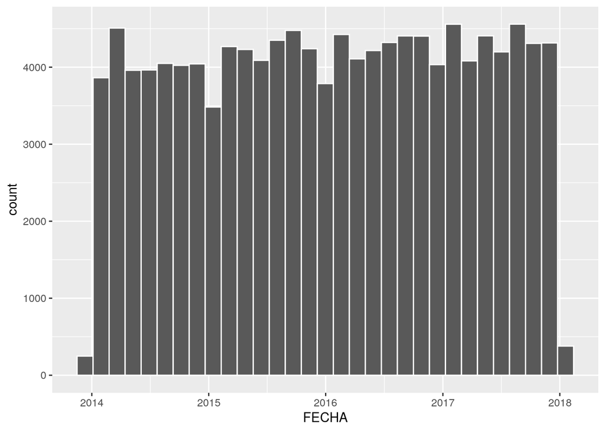

```r
#Voy a mostrar los de clase choque
datos_choque <- datos[datos$CLASE == "Choque"]
ggplot(datos_choque, aes(x=FECHA)) + geom_histogram(binwidth=50, colour="white")
```

Acá se verifica la cantidad de datos que no tienen comuna ni barrio

```r
sapply(datos_choque, function(x) sum(as.character(x) == ""))
```

```
##      FECHA        DIA    PERIODO      CLASE     BARRIO     COMUNA DIA_NOMBRE
##          0          0          0          0       9355       9352          0
##        MES
##          0
```

Se borran los datos sin comuna ni barrio para evitar inconvenientes en los datos

```r
datos_choque <- datos_choque[!datos_choque$BARRIO == "",]
datos_choque <- datos_choque[!datos_choque$COMUNA == "",]
sapply(datos_choque, function(x) sum(as.character(x) == ""))
```

```
##      FECHA        DIA    PERIODO      CLASE     BARRIO     COMUNA DIA_NOMBRE
##          0          0          0          0          0          0          0
##        MES
##          0
```

### Modelo predictivo de accidentalidad diario por Comuna

## A continuación se realiza la transformación de los datos para realizar el modelo.

```r
dias_festivos <- sample(c(0), size = nrow(datos_choque), replace = TRUE)
datos_choque_con_fest <- cbind(datos_choque,dias_festivos)
datos_choque_con_fest[datos_choque_con_fest$DIA_NOMBRE %in% c("DOMINGO"), ]$dias_festivos <- 1

festivos <- c(ymd("2014-01-01"), ymd("2014-12-24"), ymd("2014-12-25"), ymd("2014-12-31"),
              ymd("2015-01-01"), ymd("2015-12-24"), ymd("2015-12-25"), ymd("2015-12-31"),
              ymd("2016-01-01"), ymd("2016-12-24"), ymd("2016-12-25"), ymd("2016-12-31"),
              ymd("2017-01-01"), ymd("2017-12-24"), ymd("2017-12-25"), ymd("2017-12-31"))

datos_choque_con_fest[datos_choque_con_fest$FECHA %in% festivos, "dias_festivos"] <- 2

head(datos_choque_con_fest)
```

```
##         FECHA DIA PERIODO  CLASE                        BARRIO
## 1: 2016-01-01   1    2016 Choque                   Moscú No. 1
## 2: 2016-01-01   1    2016 Choque Cabecera Urbana San Cristobal
## 3: 2016-01-01   1    2016 Choque                    El Estadio
## 4: 2016-01-01   1    2016 Choque                Las Lomas No.1
## 5: 2016-01-01   1    2016 Choque                      La Palma
## 6: 2016-01-01   1    2016 Choque Cabecera San Antonio de Prado
##                                   COMUNA DIA_NOMBRE MES dias_festivos
## 1:                            Santa Cruz    VIERNES   1             2
## 2:        Corregimiento de San Cristóbal    VIERNES   1             2
## 3:                      Laureles Estadio    VIERNES   1             2
## 4:                            El Poblado    VIERNES   1             2
## 5:                                 Belén    VIERNES   1             2
## 6: Corregimiento de San Antonio de Prado    VIERNES   1             2
```

Se realiza una agrupación por periodo, fecha, dia, barrio, comuna, mes, clase y dia_festivo para conocer la cantidad

```r
#freqs <- aggregate(datos_choque$FECHA, by=list(datos_choque$FECHA), FUN=length)
freqs <- aggregate(datos_choque_con_fest$FECHA, by=list(datos_choque_con_fest$PERIODO, datos_choque_con_fest$FECHA,datos_choque_con_fest$DIA, datos_choque_con_fest$BARRIO, datos_choque_con_fest$COMUNA, datos_choque_con_fest$MES, datos_choque_con_fest$CLASE, datos_choque_con_fest$dias_festivos), FUN=length)

#Se cambian los nombres a las columnas
names (freqs) = c("Periodo", "Fecha", "Dia", "Barrio", "Comuna", "Mes", "Clase", "Dia_Fest", "Cantidad")

head(freqs)
```

```
##   Periodo      Fecha Dia   Barrio   Comuna Mes  Clase Dia_Fest Cantidad
## 1    2016 2016-01-12  12 Aranjuez Aranjuez   1 Choque        0        1
## 2    2015 2015-01-14  14 Aranjuez Aranjuez   1 Choque        0        1
## 3    2017 2017-01-14  14 Aranjuez Aranjuez   1 Choque        0        1
## 4    2014 2014-01-20  20 Aranjuez Aranjuez   1 Choque        0        1
## 5    2015 2015-01-20  20 Aranjuez Aranjuez   1 Choque        0        1
## 6    2016 2016-01-20  20 Aranjuez Aranjuez   1 Choque        0        1
```

Se convierten las variables de comuna y barrio en factor y se elimina fecha y clase ya que ya se agrupó

```r
datos_conv <- as.data.frame(unclass(freqs))
datos_conv$Barrio <- as.numeric(datos_conv$Barrio)
datos_conv$Comuna <- as.numeric(datos_conv$Comuna)
datos_conv$Comuna <- as.numeric(datos_conv$Comuna)
datos_conv$Fecha <- NULL
datos_conv$Clase <- NULL

head(datos_conv)
```

```
##   Periodo Dia Barrio Comuna Mes Dia_Fest Cantidad
## 1    2016  12     14      6   1        0        1
## 2    2015  14     14      6   1        0        1
## 3    2017  14     14      6   1        0        1
## 4    2014  20     14      6   1        0        1
## 5    2015  20     14      6   1        0        1
## 6    2016  20     14      6   1        0        1
```

Para el modelamiento se utiliza k vecinos más cercanos, para encontrar el k ideal se utiliza solo el 10% de los datos

```r
n<-dim(datos_conv)[1]
n_vl<-round(n*0.90)
set.seed(20190930) # Se fija la semilla para obtener resultados reproducibles
ix_vl<-sample(1:n,n_vl,replace = FALSE)
datos_obtener_k <- datos_conv[-ix_vl, c("Dia", "Barrio",  "Comuna", "Mes", "Dia_Fest", "Cantidad")]
head(datos_obtener_k)
```

```
##    Dia Barrio Comuna Mes Dia_Fest Cantidad
## 13  11     43      6   1        0        1
## 22  26     43      6   1        0        1
## 24  28     43      6   1        0        1
## 32  30     45      6   1        0        1
## 37  15     55      6   1        0        1
## 42  23     55      6   1        0        1
```

Se procede a encontrar el módelo con mejor K

```r
ctrl<-trainControl(method = "LGOCV",p=0.75, number = 20)
set.seed(123)
modelo_entrenamiento<-train(Cantidad ~ Dia+Barrio+Comuna+Mes+Dia_Fest,
             data       = datos_obtener_k,
             method     = "knn",
             preProcess = c("center","scale"),
             tuneGrid   = expand.grid(k = 1:30),
             trControl  = ctrl,
             metric     = "RMSE")
```

Se verifica el modelo

```r
print(modelo_entrenamiento)
```

```
## k-Nearest Neighbors
##
## 8096 samples
##    5 predictor
##
## Pre-processing: centered (5), scaled (5)
## Resampling: Repeated Train/Test Splits Estimated (20 reps, 75%)
## Summary of sample sizes: 6073, 6073, 6073, 6073, 6073, 6073, ...
## Resampling results across tuning parameters:
##
##   k   RMSE       Rsquared    MAE
##    1  1.0393199  0.02848082  0.5734800
##    2  0.9047045  0.04170910  0.5471602
##    3  0.8568751  0.05024518  0.5419374
##    4  0.8324184  0.05648294  0.5411154
```

[output cut: 29 more lines]

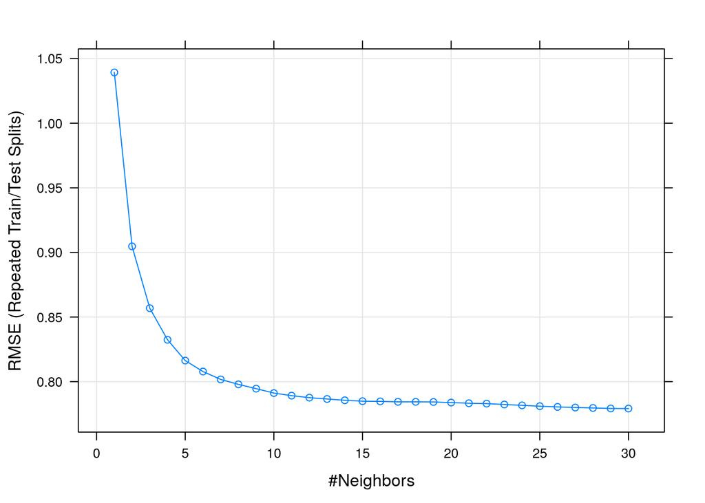

```r
plot(modelo_entrenamiento)
```

Se vuelve a generar el módelo con K=15 que es adecuado según la gráfica pero con todos los datos

```r
modelo_entrenamiento2<-train(Cantidad ~ Dia+Barrio+Comuna+Mes+Dia_Fest,
             data       = datos_conv,
             method     = "knn",
             preProcess = c("center","scale"),
             tuneGrid   = expand.grid(k = 15),
             metric     = "RMSE")
```

```r
modelo_entrenamiento2
```

```
## k-Nearest Neighbors
##
## 80962 samples
##     5 predictor
##
## Pre-processing: centered (5), scaled (5)
## Resampling: Bootstrapped (25 reps)
## Summary of sample sizes: 80962, 80962, 80962, 80962, 80962, 80962, ...
## Resampling results:
##
##   RMSE       Rsquared    MAE
##   0.7768906  0.07689428  0.5193435
##
## Tuning parameter 'k' was held constant at a value of 15
```

```r
modelo_entrenamiento2$finalModel
```

```
## 15-nearest neighbor regression model
```

```r
predicciones_raw <- predict(modelo_entrenamiento2, newdata = datos_conv)
predicciones_raw <- round(predicciones_raw)
error_test <- mean(predicciones_raw != datos_conv$Cantidad)
paste("El error de test del modelo:", round(error_test*100, 2), "%")
```

```
## [1] "El error de test del modelo: 35.68 %"
```

Se generan los datos de validación

```r
datos_v <- as.data.table(fread("data/validate/Incidentes_georreferenciados_2018.csv", sep = ","), header=TRUE)

datos_val <- datos_v[,c("X","Y","OBJECTID", "RADICADO", "HORA", "DIRECCION", "DIRECCION_ENC", "CBML", "TIPO_GEOCOD",   "MES_NOMBRE","Y_MAGNAMED", "X_MAGNAMED", "LONGITUD", "LATITUD", "GRAVEDAD", "DISENO"):=NULL]
datos_v$FECHA = substr(datos_v$FECHA,1,10)
datos_v$FECHA <- as.Date(datos_v$FECHA)
datos_choque_v <- datos_v[datos_v$CLASE == "Choque"]

datos_choque_v <- datos_choque_v[!datos_choque_v$BARRIO == "",]
datos_choque_v <- datos_choque_v[!datos_choque_v$COMUNA == "",]

dias_festivos <- sample(c(0), size = nrow(datos_choque_v), replace = TRUE)
datos_choque_con_fest_v <- cbind(datos_choque_v,dias_festivos)
datos_choque_con_fest_v[datos_choque_con_fest_v$DIA_NOMBRE %in% c("DOMINGO"), ]$dias_festivos <- 1
festivos <- c(ymd("2018-01-01"), ymd("2018-12-24"), ymd("2018-12-25"), ymd("2018-12-31"))
datos_choque_con_fest_v[datos_choque_con_fest_v$FECHA %in% festivos, "dias_festivos"] <- 2
#freqs <- aggregate(datos_choque$FECHA, by=list(datos_choque$FECHA), FUN=length)
freqs_v <- aggregate(datos_choque_con_fest_v$FECHA, by=list(datos_choque_con_fest_v$PERIODO, datos_choque_con_fest_v$FECHA,datos_choque_con_fest_v$DIA, datos_choque_con_fest_v$BARRIO, datos_choque_con_fest_v$COMUNA, datos_choque_con_fest_v$MES, datos_choque_con_fest_v$CLASE, datos_choque_con_fest_v$dias_festivos), FUN=length)

#Se cambian los nombres a las columnas
names (freqs_v) = c("Periodo", "Fecha", "Dia", "Barrio", "Comuna", "Mes", "Clase", "Dia_Fest", "Cantidad")
datos_conv_v <- as.data.frame(unclass(freqs_v))
datos_conv_v$Barrio <- as.numeric(datos_conv_v$Barrio)
datos_conv_v$Comuna <- as.numeric(datos_conv_v$Comuna)
datos_conv_v$Fecha <- NULL
datos_conv_v$Clase <- NULL

head(datos_conv_v)
```

```
##   Periodo Dia Barrio Comuna Mes Dia_Fest Cantidad
## 1    2018  18     16      1   1        0        1
## 2    2018  24     16      1   1        0        1
## 3    2018   3     40      1   1        0        1
## 4    2018   9     40      1   1        0        1
## 5    2018  20     40      1   1        0        1
## 6    2018  23     40      1   1        0        2
```

Se hace la prueba con el modelo y los datos de validación y se encuentra el MSE

```r
modelo_entrenamiento2$finalModel
```

```
## 15-nearest neighbor regression model
```

```r
predicciones_v <- predict(modelo_entrenamiento2, newdata = datos_conv_v)
predicciones_v <- round(predicciones_v)
error_test <- mean(predicciones_v != datos_conv_v$Cantidad)
paste("El error de test del modelo:", round(error_test*100, 2), "%")
```

```
## [1] "El error de test del modelo: 33.32 %"
```

### Se comprueba que la diferencia entre entranamiento y validación es 35.68% - 33.32% que es igual a 2.36% lo que evidencia que no está sobreentrenado

Ahora se generan todas las combinaciones posibles de las variables utilizadas para el año 2020

```r
#Se hace una multiplicación de columnas entre el periodo 2020 y los diferentes días que existan
ano <- c('2020')
dia <- aggregate(datos_conv_v$Dia, by=list(datos_conv_v$Dia), FUN=length)$Group.1
df <- merge(x = ano, y = dia, by = NULL)
#Se multiplica lo que se lleva hasta el momento con la agrupación de barrios y su respectiva comuna
barrio_comuna <- aggregate(datos_conv_v$Barrio, by=list(datos_conv_v$Barrio, datos_conv_v$Comuna), FUN=length)
barrio_comuna <- cbind(barrio_comuna$Group.1, barrio_comuna$Group.2)
df <- merge(x = df, y = barrio_comuna, by = NULL)
#Se multiplica también por los meses del año
mes <- aggregate(datos_conv_v$Mes, by=list(datos_conv_v$Mes), FUN=length)$Group.1
df <- merge(x = df, y = mes, by = NULL)
#Se agregan los días festivos que se han puesto en los otros modelos, que es los domingos y festivos
dias_festivos <- sample(c(0), size = nrow(df), replace = TRUE)
df <- cbind(df,dias_festivos)
names (df) = c("Periodo", "Dia", "Barrio", "Comuna", "Mes", "Dia_Fest")
df[df$Dia %in% c(30), ]$Dia_Fest <- 1
festivos <- c(ymd("2018-01-01"), ymd("2018-12-24"), ymd("2018-12-25"), ymd("2018-12-31"))
df[df$Periodo %in% c("2020") & df$Dia %in% c(10) & df$Mes %in% c(1), ]$Dia_Fest <- 2
head(df)
```

```
##   Periodo Dia Barrio Comuna Mes Dia_Fest
## 1    2020   1     16      1   1        0
## 2    2020   2     16      1   1        0
## 3    2020   3     16      1   1        0
## 4    2020   4     16      1   1        0
## 5    2020   5     16      1   1        0
## 6    2020   6     16      1   1        0
```

Se realiza la predicción del 2020

```r
predicciones_nuevas <- predict(modelo_entrenamiento2, newdata = df)
#predicciones_nuevas <- round(predicciones_nuevas)
```

Se completa la predicción con las otras columnas correspondientes

```r
data_frame_pred <- cbind(df, predicciones_nuevas)
fechas<-apply(cbind(2020,data_frame_pred$Mes,data_frame_pred$Dia),1,paste,collapse="-")
fechas<-as.Date(fechas,"%Y-%m-%d")
data_frame_pred <- cbind(data_frame_pred, fechas)
head(data_frame_pred)
```

```
##   Periodo Dia Barrio Comuna Mes Dia_Fest predicciones_nuevas     fechas
## 1    2020   1     16      1   1        0            1.000000 2020-01-01
## 2    2020   2     16      1   1        0            1.000000 2020-01-02
## 3    2020   3     16      1   1        0            1.000000 2020-01-03
## 4    2020   4     16      1   1        0            1.058824 2020-01-04
## 5    2020   5     16      1   1        0            1.117647 2020-01-05
## 6    2020   6     16      1   1        0            1.157895 2020-01-06
```

Se verifica que se pueda graficar, además se agregan los nombres de las comunas

```r
datos_conv_v <- as.data.frame(unclass(freqs_v))
datos_conv_v$com_num <- as.numeric(datos_conv_v$Comuna)
comunas_num <- aggregate(datos_conv_v$com_num, by=list(datos_conv_v$com_num), FUN=length)$Group.1
comunas_nom <- aggregate(datos_conv_v$Comuna, by=list(datos_conv_v$Comuna), FUN=length)$Group.1
data_frame_pred$Comuna_nombre <- cut(data_frame_pred$Comuna, breaks = c(comunas_num,23), labels = comunas_nom, right = FALSE)

d <- data_frame_pred %>%
                filter(Comuna_nombre == "Aranjuez") %>%
                group_by(fechas) %>% summarise(sum = sum(predicciones_nuevas))
```

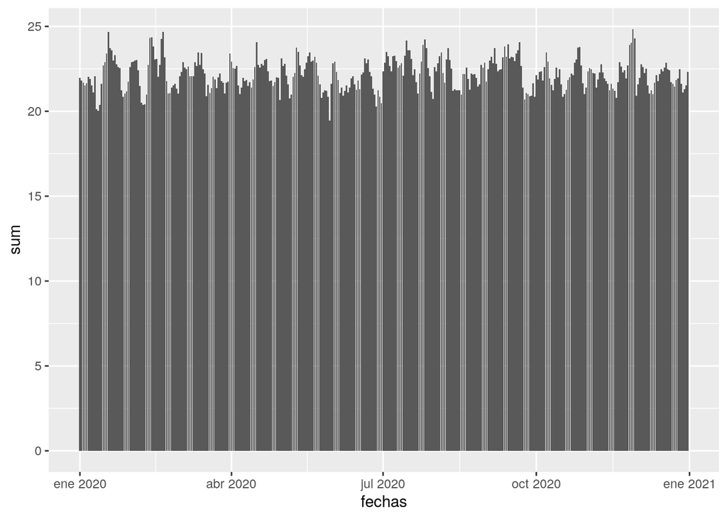

```r
ggplot(data = d,aes(x = fechas, y = sum)) + geom_bar(stat="identity")
```

Se guarda el objeto donde se realizó la predicción para que sea consultado por la aplicación shiny

```r
save(data_frame_pred, file = "Aplicacion/prediccion_diaria.RData")
```

### Modelo predictivo de accidentalidad semanal por Comuna

## A continuación se realiza la transformación de los datos para realizar el modelo.

A partir de la fecha se obtiene la semana del año correspondiente, también se eliminan las filas con barrios y comunas vacías

```r
datos_choque_sem <- datos_choque
datos_choque_sem$semana = week(datos_choque_sem$FECHA)
datos_choque_sem <- datos_choque_sem[!datos_choque_sem$BARRIO == "",]
datos_choque_sem <- datos_choque_sem[!datos_choque_sem$COMUNA == "",]
sapply(datos_choque_sem, function(x) sum(as.character(x) == ""))
```

```
##      FECHA        DIA    PERIODO      CLASE     BARRIO     COMUNA DIA_NOMBRE
##          0          0          0          0          0          0          0
##        MES     semana
##          0          0
```

Se realiza una agrupación por periodo, periodo - semana, barrio, comuna, mes, clase y semana para conocer la cantidad

```r
#Se agrega una columna con la semana y el periodo para agruparlas juntas
datos_choque_sem$semana_periodo <- apply(cbind(datos_choque_sem$PERIODO,datos_choque_sem$semana),1,paste,collapse="-")

freq_sem <- aggregate(datos_choque_sem$semana_periodo, by=list(datos_choque_sem$semana_periodo, datos_choque_sem$PERIODO, datos_choque_sem$BARRIO, datos_choque_sem$COMUNA, datos_choque_sem$MES, datos_choque_sem$CLASE, datos_choque_sem$semana), FUN=length)

#Se cambian los nombres a las columnas
names (freq_sem) = c("Periodo_semana","Periodo", "Barrio", "Comuna", "Mes", "Clase","Semana", "Cantidad")
head(freq_sem)
```

```
##   Periodo_semana Periodo   Barrio   Comuna Mes  Clase Semana Cantidad
## 1         2016-1    2016 Aranjuez Aranjuez   1 Choque      1        1
## 2         2014-1    2014   Berlin Aranjuez   1 Choque      1        3
## 3         2015-1    2015   Berlin Aranjuez   1 Choque      1        1
## 4         2016-1    2016   Berlin Aranjuez   1 Choque      1        1
## 5         2014-1    2014 Brasilia Aranjuez   1 Choque      1        2
## 6         2016-1    2016 Brasilia Aranjuez   1 Choque      1        1
```

Se convierten las variables de comuna y barrio en factor y se elimina periodo_semana y clase ya que ya se agrupó

```r
datos_conv_sem <- as.data.frame(unclass(freq_sem))
datos_conv_sem$Barrio <- as.numeric(datos_conv_sem$Barrio)
datos_conv_sem$Comuna <- as.numeric(datos_conv_sem$Comuna)
datos_conv_sem$Periodo_semana <- NULL
datos_conv_sem$Clase <- NULL
head(datos_conv_sem)
```

```
##   Periodo Barrio Comuna Mes Semana Cantidad
## 1    2016     14      6   1      1        1
## 2    2014     43      6   1      1        3
## 3    2015     43      6   1      1        1
## 4    2016     43      6   1      1        1
## 5    2014     55      6   1      1        2
## 6    2016     55      6   1      1        1
```

Para el modelamiento se utiliza k vecinos más cercanos, para encontrar el k ideal, se utiliza solo el 20% de los datos por procesos computacionales

```r
n<-dim(datos_conv_sem)[1]
n_vl<-round(n*0.80)
set.seed(20190930) # Se fija la semilla para obtener resultados reproducibles
ix_vl<-sample(1:n,n_vl,replace = FALSE)
datos_obtener_k_sem <- datos_conv_sem[-ix_vl, c("Barrio", "Comuna", "Semana", "Cantidad")]
head(datos_obtener_k_sem)
```

```
##    Barrio Comuna Semana Cantidad
## 3      43      6      1        1
## 5      55      6      1        2
## 7      55      6      1        1
## 9      65      6      1        3
## 11     65      6      1        2
## 14    134      6      1        1
```

Se procede a encontrar el módelo con mejor K

```r
ctrl<-trainControl(method = "LGOCV",p=0.75, number = 20)
set.seed(20190930)
modelo_entrenamiento_sem<-train(Cantidad ~ Barrio+Comuna+Semana,
             data       = datos_obtener_k_sem,
             method     = "knn",
             preProcess = c("center","scale"),
             tuneGrid   = expand.grid(k = 1:30),
             trControl  = ctrl,
             metric     = "RMSE")
```

Se verifica el modelo

```r
print(modelo_entrenamiento_sem)
```

```
## k-Nearest Neighbors
##
## 7625 samples
##    3 predictor
##
## Pre-processing: centered (3), scaled (3)
## Resampling: Repeated Train/Test Splits Estimated (20 reps, 75%)
## Summary of sample sizes: 5720, 5720, 5720, 5720, 5720, 5720, ...
## Resampling results across tuning parameters:
##
##   k   RMSE      Rsquared   MAE
##    1  2.796862  0.2564005  1.724653
##    2  2.575566  0.2827591  1.655334
##    3  2.513761  0.2857509  1.645060
##    4  2.493851  0.2816793  1.645120
```

[output cut: 29 more lines]

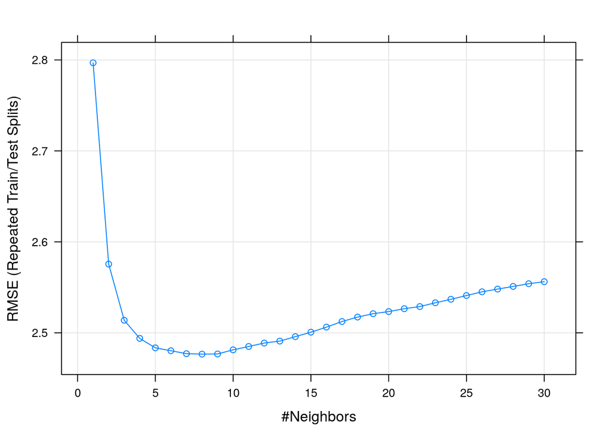

```r
plot(modelo_entrenamiento_sem)
```

Se vuelve a generar el módelo con K=8 que es adecuado según la gráfica pero con todos los datos

```r
modelo_entrenamiento2_sem<-train(Cantidad ~ Barrio+Comuna+Semana,
             data       = datos_conv_sem,
             method     = "knn",
             preProcess = c("center","scale"),
             tuneGrid   = expand.grid(k = 8),
             metric     = "RMSE")
```

```r
modelo_entrenamiento2_sem
```

```
## k-Nearest Neighbors
##
## 38123 samples
##     3 predictor
##
## Pre-processing: centered (3), scaled (3)
## Resampling: Bootstrapped (25 reps)
## Summary of sample sizes: 38123, 38123, 38123, 38123, 38123, 38123, ...
## Resampling results:
##
##   RMSE      Rsquared   MAE
##   2.232219  0.4336644  1.464273
##
## Tuning parameter 'k' was held constant at a value of 8
```

```r
modelo_entrenamiento2_sem$finalModel
```

```
## 8-nearest neighbor regression model
```

```r
predicciones_raw_sem <- predict(modelo_entrenamiento2_sem, newdata = datos_conv_sem)
predicciones_raw_sem <- round(predicciones_raw_sem)
error_test <- mean(predicciones_raw_sem != datos_conv_sem$Cantidad)
paste("El error de test del modelo:", round(error_test*100, 2), "%")
```

```
## [1] "El error de test del modelo: 67.09 %"
```

Se obtienen los datos para validar

```r
datos_choque_v_sem <- datos_choque_v
#Se agrega una columna con la semana y el periodo para agruparlas juntas
datos_choque_v_sem$semana = week(datos_choque_v_sem$FECHA)
datos_choque_v_sem$semana_periodo <- apply(cbind(datos_choque_v_sem$PERIODO,datos_choque_v_sem$semana),1,paste,collapse="-")

freq_sem_v <- aggregate(datos_choque_v_sem$semana_periodo, by=list(datos_choque_v_sem$semana_periodo, datos_choque_v_sem$PERIODO, datos_choque_v_sem$BARRIO, datos_choque_v_sem$COMUNA, datos_choque_v_sem$MES, datos_choque_v_sem$CLASE, datos_choque_v_sem$semana), FUN=length)

#Se cambian los nombres a las columnas
names (freq_sem_v) = c("Periodo_semana","Periodo", "Barrio", "Comuna", "Mes", "Clase","Semana", "Cantidad")

datos_conv_sem_v <- as.data.frame(unclass(freq_sem_v))
datos_conv_sem_v$Barrio <- as.numeric(datos_conv_sem_v$Barrio)
datos_conv_sem_v$Comuna <- as.numeric(datos_conv_sem_v$Comuna)
datos_conv_sem_v$Periodo_semana <- NULL
datos_conv_sem_v$Clase <- NULL
head(datos_conv_sem_v)
```

```
##   Periodo Barrio Comuna Mes Semana Cantidad
## 1    2018     16      1   1      1        1
## 2    2018     40      1   1      1        1
## 3    2018     52      1   1      1        2
## 4    2018     62      1   1      1        3
## 5    2018    162      1   1      1        1
## 6    2018    170      1   1      1        2
```

Se hace la prueba con el modelo y los datos de validación y se encuentra el MSE

```r
modelo_entrenamiento2_sem$finalModel
```

```
## 8-nearest neighbor regression model
```

```r
predicciones_v_sem <- predict(modelo_entrenamiento2_sem, newdata = datos_conv_sem_v)
predicciones_v_sem <- round(datos_conv_sem_v)
error_test <- mean(predicciones_v_sem != datos_conv_sem_v$Cantidad)
paste("El error de test del modelo:", round(error_test*100, 2), "%")
```

```
## [1] "El error de test del modelo: 80.8 %"
```

Ahora se generan todas las combinaciones posibles de las variables utilizadas para el año 2020

```r
#Se hace una multiplicación de columnas con el periodo 2020
ano <- c('2020')
semana <- aggregate(datos_conv_sem_v$Semana, by=list(datos_conv_sem_v$Semana, datos_conv_sem_v$Mes), FUN=length)
semana <- cbind(semana$Group.1, semana$Group.2)
df <- merge(x = ano, y = semana, by = NULL)
barrio_comuna <- aggregate(datos_conv_sem_v$Barrio, by=list(datos_conv_sem_v$Barrio, datos_conv_sem_v$Comuna), FUN=length)
barrio_comuna <- cbind(barrio_comuna$Group.1, barrio_comuna$Group.2)
df <- merge(x = df, y = barrio_comuna, by = NULL)
names(df) = c("Periodo", "Semana", "Mes", "Barrio", "Comuna")
head(df)
```

```
##   Periodo Semana Mes Barrio Comuna
## 1    2020      1   1     16      1
## 2    2020      2   1     16      1
## 3    2020      3   1     16      1
## 4    2020      4   1     16      1
## 5    2020      5   1     16      1
## 6    2020      5   2     16      1
```

Se realiza la predicción del 2020

```r
predicciones_nuevas <- predict(modelo_entrenamiento2_sem, newdata = df)
```

Se completa la predicción con las otras columnas correspondientes

```r
data_frame_pred_sem <- cbind(df, predicciones_nuevas)
head(data_frame_pred_sem)
```

```
##   Periodo Semana Mes Barrio Comuna predicciones_nuevas
## 1    2020      1   1     16      1            1.625000
## 2    2020      2   1     16      1            1.625000
## 3    2020      3   1     16      1            1.555556
## 4    2020      4   1     16      1            1.545455
## 5    2020      5   1     16      1            1.928571
## 6    2020      5   2     16      1            1.928571
```

Se verifica que se pueda graficar, además se agregan los nombres de las comunas

```r
datos_conv_v_sem <- as.data.frame(unclass(freq_sem_v))
datos_conv_v_sem$com_num <- as.numeric(datos_conv_v_sem$Comuna)
comunas_num <- aggregate(datos_conv_v_sem$com_num, by=list(datos_conv_v_sem$com_num), FUN=length)$Group.1
comunas_nom <- aggregate(datos_conv_v_sem$Comuna, by=list(datos_conv_v_sem$Comuna), FUN=length)$Group.1
data_frame_pred_sem$Comuna_nombre <- cut(data_frame_pred_sem$Comuna, breaks = c(comunas_num,23), labels = comunas_nom, right = FALSE)

d_sem <- data_frame_pred_sem %>%
                filter(Comuna_nombre == "Aranjuez") %>%
                group_by(Semana) %>% summarise(sum = sum(predicciones_nuevas))
```

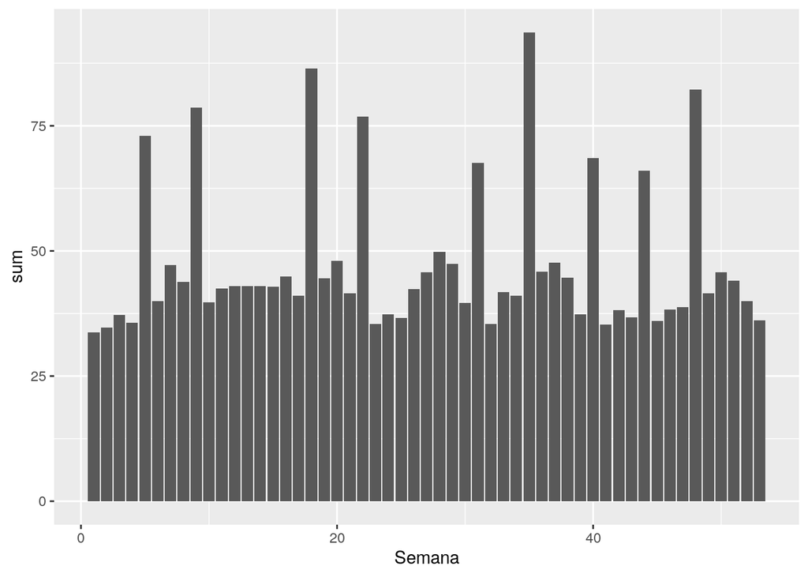

```r
ggplot(data = d_sem,aes(x = Semana, y = sum)) + geom_bar(stat="identity")
```

Se guarda el objeto donde se realizó la predicción para que sea consultado por la aplicación shiny

```r
save(data_frame_pred,data_frame_pred_sem, file = "Aplicacion/prediccion_diaria.RData")
```

### Modelo predictivo de accidentalidad mensual por Comuna

## A continuación se realiza la transformación de los datos para realizar el modelo.

Este modelo es más sencillo, ya que el mes es una variable dada en el conjunto de datos, también se eliminan las filas con barrios y comunas vacías

```r
datos_choque_mes <- datos_choque
datos_choque_mes <- datos_choque_mes[!datos_choque_mes$BARRIO == "",]
datos_choque_mes <- datos_choque_mes[!datos_choque_mes$COMUNA == "",]
sapply(datos_choque_mes, function(x) sum(as.character(x) == ""))
```

```
##      FECHA        DIA    PERIODO      CLASE     BARRIO     COMUNA DIA_NOMBRE
##          0          0          0          0          0          0          0
##        MES
##          0
```

Se realiza una agrupación por periodo, periodo - mes, barrio, comuna, mes y clase para conocer la cantidad

```r
#Se agrega una columna con mes y el periodo para agruparlas juntas
datos_choque_mes$mes_periodo <- apply(cbind(datos_choque_mes$PERIODO,datos_choque_mes$MES),1,paste,collapse="-")

freq_mes <- aggregate(datos_choque_mes$mes_periodo, by=list( datos_choque_mes$PERIODO, datos_choque_mes$BARRIO, datos_choque_mes$COMUNA, datos_choque_mes$MES, datos_choque_mes$CLASE), FUN=length)

#Se cambian los nombres a las columnas
names (freq_mes) = c("Periodo", "Barrio", "Comuna", "Mes", "Clase", "Cantidad")
head(freq_mes)
```

```
##   Periodo   Barrio   Comuna Mes  Clase Cantidad
## 1    2014 Aranjuez Aranjuez   1 Choque        2
## 2    2015 Aranjuez Aranjuez   1 Choque        2
## 3    2016 Aranjuez Aranjuez   1 Choque        5
## 4    2017 Aranjuez Aranjuez   1 Choque        4
## 5    2014   Berlin Aranjuez   1 Choque        8
## 6    2015   Berlin Aranjuez   1 Choque        7
```

Se convierten las variables de comuna y barrio en factor y se elimina periodo_semana y clase ya que ya se agrupó

```r
datos_conv_mes <- as.data.frame(unclass(freq_mes))
datos_conv_mes$Barrio <- as.numeric(datos_conv_mes$Barrio)
datos_conv_mes$Comuna <- as.numeric(datos_conv_mes$Comuna)
datos_conv_mes$Clase <- NULL
head(datos_conv_mes)
```

```
##   Periodo Barrio Comuna Mes Cantidad
## 1    2014     14      6   1        2
## 2    2015     14      6   1        2
## 3    2016     14      6   1        5
## 4    2017     14      6   1        4
## 5    2014     43      6   1        8
## 6    2015     43      6   1        7
```

Para el modelamiento se utiliza k vecinos más cercanos, para encontrar el k ideal, se utiliza solo el 40% de los datos por procesos computacionales

```r
n<-dim(datos_conv_mes)[1]
n_vl<-round(n*0.60)
set.seed(20190930) # Se fija la semilla para obtener resultados reproducibles
ix_vl<-sample(1:n,n_vl,replace = FALSE)
datos_obtener_k_mes <- datos_conv_mes[-ix_vl, c("Barrio", "Comuna", "Mes", "Cantidad")]
head(datos_obtener_k_mes)
```

```
##    Barrio Comuna Mes Cantidad
## 1      14      6   1        2
## 2      14      6   1        2
## 3      14      6   1        5
## 6      43      6   1        7
## 9      45      6   1        2
## 10     45      6   1        1
```

Se procede a encontrar el módelo con mejor K

```r
ctrl<-trainControl(method = "LGOCV",p=0.75, number = 20)
set.seed(20190930)
modelo_entrenamiento_mes <-train(Cantidad ~ Barrio+Comuna+Mes,
             data       = datos_obtener_k_mes,
             method     = "knn",
             preProcess = c("center","scale"),
             tuneGrid   = expand.grid(k = 1:30),
             trControl  = ctrl,
             metric     = "RMSE")
```

Se verifica el modelo

```r
print(modelo_entrenamiento_mes)
```

```
## k-Nearest Neighbors
##
## 4780 samples
##    3 predictor
##
## Pre-processing: centered (3), scaled (3)
## Resampling: Repeated Train/Test Splits Estimated (20 reps, 75%)
## Summary of sample sizes: 3587, 3587, 3587, 3587, 3587, 3587, ...
## Resampling results across tuning parameters:
##
##   k   RMSE       Rsquared   MAE
##    1   9.162323  0.4560078  5.173599
##    2   9.849059  0.3363098  5.937849
##    3   9.903478  0.2961554  6.150507
##    4   9.810919  0.2903870  6.190794
```

[output cut: 29 more lines]

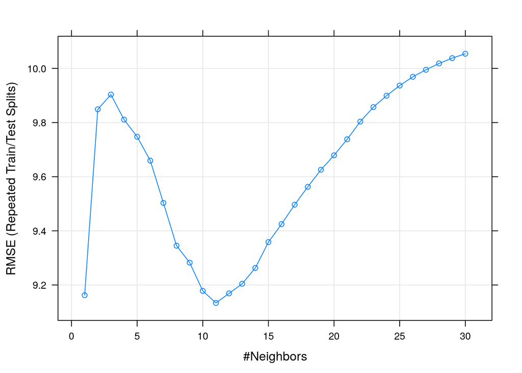

```r
plot(modelo_entrenamiento_mes)
```

Se vuelve a generar el módelo con K=11 que es adecuado según la gráfica pero con todos los datos

```r
modelo_entrenamiento2_mes<-train(Cantidad ~ Barrio+Comuna+Mes,
             data       = datos_conv_mes,
             method     = "knn",
             preProcess = c("center","scale"),
             tuneGrid   = expand.grid(k = 11),
             metric     = "RMSE")
```

```r
modelo_entrenamiento2_mes
```

```
## k-Nearest Neighbors
##
## 11951 samples
##     3 predictor
##
## Pre-processing: centered (3), scaled (3)
## Resampling: Bootstrapped (25 reps)
## Summary of sample sizes: 11951, 11951, 11951, 11951, 11951, 11951, ...
## Resampling results:
##
##   RMSE      Rsquared   MAE
##   9.536956  0.3228615  6.117667
##
## Tuning parameter 'k' was held constant at a value of 11
```

Se prueban los datos de entrenamiento

```r
modelo_entrenamiento2_mes$finalModel
```

```
## 11-nearest neighbor regression model
```

```r
predicciones_raw_mes <- predict(modelo_entrenamiento2_mes, newdata = datos_conv_mes)
predicciones_raw_mes <- round(predicciones_raw_mes)
error_test <- mean(predicciones_raw_mes != datos_conv_mes$Cantidad)
paste("El error de test del modelo:", round(error_test*100, 2), "%")
```

```
## [1] "El error de test del modelo: 90.88 %"
```

Se obtienen los datos para validar

```r
datos_choque_v_mes <- datos_choque_v

#Se agrega una columna con mes y el periodo para agruparlas juntas
datos_choque_v_mes$mes_periodo <- apply(cbind(datos_choque_v_mes$PERIODO,datos_choque_v_mes$MES),1,paste,collapse="-")

freq_mes_v <- aggregate(datos_choque_v_mes$mes_periodo, by=list( datos_choque_v_mes$PERIODO, datos_choque_v_mes$BARRIO, datos_choque_v_mes$COMUNA, datos_choque_v_mes$MES, datos_choque_v_mes$CLASE), FUN=length)

#Se cambian los nombres a las columnas
names (freq_mes_v) = c("Periodo", "Barrio", "Comuna", "Mes", "Clase", "Cantidad")

datos_choque_v_mes <- as.data.frame(unclass(freq_mes_v))
datos_choque_v_mes$Barrio <- as.numeric(datos_choque_v_mes$Barrio)
datos_choque_v_mes$Comuna <- as.numeric(datos_choque_v_mes$Comuna)
datos_choque_v_mes$Clase <- NULL
```

Se hace la prueba con el modelo y los datos de validación y se encuentra el MSE

```r
modelo_entrenamiento2_mes$finalModel
```

```
## 11-nearest neighbor regression model
```

```r
predicciones_v_mes <- predict(modelo_entrenamiento2_mes, newdata = datos_choque_v_mes)
predicciones_v_mes <- round(predicciones_v_mes)
error_test <- mean(predicciones_v_mes != datos_choque_v_mes$Cantidad)
paste("El error de test del modelo:", round(error_test*100, 2), "%")
```

```
## [1] "El error de test del modelo: 93.46 %"
```

### Se comprueba que la diferencia entre entranamiento y validación es 90.88% - 93.46% que es igual a 2.58% lo que evidencia que no está sobreentrenado

Ahora se generan todas las combinaciones posibles de las variables utilizadas para el año 2020

```r
#Se hace una multiplicación de columnas con el periodo 2020
ano <- c('2020')
mes <- aggregate(datos_choque_v_mes$Mes, by=list(datos_choque_v_mes$Mes), FUN=length)$Group.1
df <- merge(x = ano, y = mes, by = NULL)
barrio_comuna <- aggregate(datos_choque_v_mes$Barrio, by=list(datos_choque_v_mes$Barrio, datos_choque_v_mes$Comuna), FUN=length)
barrio_comuna <- cbind(barrio_comuna$Group.1, barrio_comuna$Group.2)
df <- merge(x = df, y = barrio_comuna, by = NULL)
names(df) = c("Periodo", "Mes", "Barrio", "Comuna")
head(df)
```

```
##   Periodo Mes Barrio Comuna
## 1    2020   1     16      1
## 2    2020   2     16      1
## 3    2020   3     16      1
## 4    2020   4     16      1
## 5    2020   5     16      1
## 6    2020   6     16      1
```

Se realiza la predicción del 2020

```r
predicciones_nuevas <- predict(modelo_entrenamiento2_mes, newdata = df)
```

Se completa la predicción con las otras columnas correspondientes

```r
data_frame_pred_mes <- cbind(df, predicciones_nuevas)
head(data_frame_pred_mes)
```

```
##   Periodo Mes Barrio Comuna predicciones_nuevas
## 1    2020   1     16      1            5.000000
## 2    2020   2     16      1            3.714286
## 3    2020   3     16      1            4.000000
## 4    2020   4     16      1            3.846154
## 5    2020   5     16      1            4.166667
## 6    2020   6     16      1            4.090909
```

Se verifica que se pueda graficar, además se agregan los nombres de las comunas

```r
datos_conv_v_mes <- as.data.frame(unclass(freq_sem_v))
datos_conv_v_mes$com_num <- as.numeric(datos_conv_v_mes$Comuna)
comunas_num <- aggregate(datos_conv_v_mes$com_num, by=list(datos_conv_v_mes$com_num), FUN=length)$Group.1
comunas_nom <- aggregate(datos_conv_v_mes$Comuna, by=list(datos_conv_v_mes$Comuna), FUN=length)$Group.1
data_frame_pred_mes$Comuna_nombre <- cut(data_frame_pred_mes$Comuna, breaks = c(comunas_num,23), labels = comunas_nom, right = FALSE)

d_mes <- data_frame_pred_mes %>%
                filter(Comuna_nombre == "Aranjuez") %>%
                group_by(Mes) %>% summarise(sum = sum(predicciones_nuevas))
```

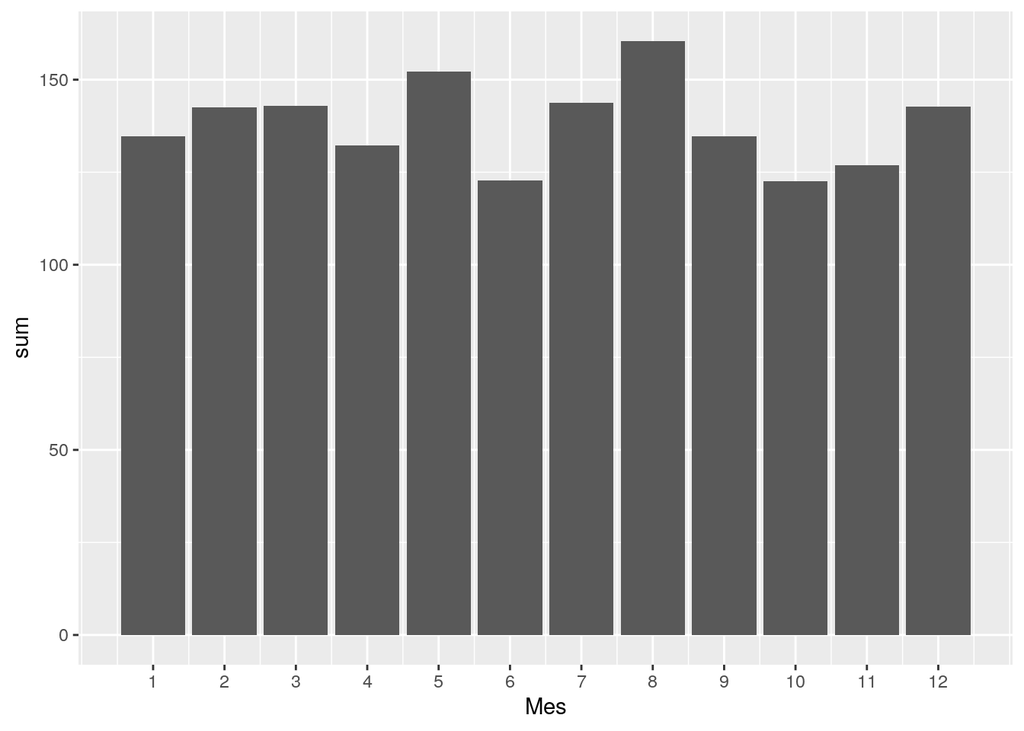

```r
ggplot(data = d_mes,aes(x = Mes, y = sum)) + geom_bar(stat="identity") + scale_x_continuous(breaks=c(1,2,3,4,5,6,7,8,9,10,11,12))
```

Se guarda el objeto donde se realizó la predicción para que sea consultado por la aplicación shiny

```r
save(data_frame_pred,data_frame_pred_sem,data_frame_pred_mes, file = "Aplicacion/prediccion_diaria.RData")
```

## Referencias

- https://www.diegocalvo.es/analisis-de-series-temporales-en-r-arima/
- https://rpubs.com/palominoM/series
- https://stat.ethz.ch/pipermail/r-help-es/2009-November/000433.html
- https://www.diegocalvo.es/manipulacion-datos-r-forma-simple/
- https://www.iteramos.com/pregunta/51161/la-comprension-de-las-fechas-y-el-trazado-de-un-histograma-con-ggplot2-en-r
- https://es.r4ds.hadley.nz/fechas-y-horas.html
- https://www.institutomora.edu.mx/testU/SitePages/martinpaladino/series_de_tiempo_con_R.html#agregar-series-de-tiempo-en-anos-semestres-trimestres.
- http://estadistica-dma.ulpgc.es/cursoR4ULPGC/14-seriesTemporales.html
- https://www.earthdatascience.org/courses/earth-analytics/time-series-data/date-class-in-r/
- http://www.scielo.org.co/pdf/dyna/v78n165/a30v78n165.pdf
- https://www.r-bloggers.com/2018/07/how-to-aggregate-data-in-r/
- https://rpubs.com/Rortizdu/140158
- https://biocosas.github.io/R/020_gestion_datos.html
- https://bookdown.org/content/2274/metodos-de-clasificacion.html#algoritmo-k-vecinos-mas-cercanos
- https://es.quora.com/C%C3%B3mo-puedo-eliminar-variables-columnas-en-RStudio
- https://danielredondo.com/posts/20200219_calendario_laboral/
- https://topepo.github.io/caret/model-training-and-tuning.html
- https://dataaspirant.com/knn-implementation-r-using-caret-package/